# Laboratório R

## Laboratório 2

### Visualização de Dados com ggplot2

As 20 primeiras linhas do data frame flights! ? possivel rolar para a direita na versão html!

| year | month | day | dep_time | sched_dep_time | dep_delay | arr_time | sched_arr_time | arr_delay | carrier | flight | tailnum | origin | dest | air_time | distance | hour | minute | time_hour |
| --- | --- | --- | --- | --- | --- | --- | --- | --- | --- | --- | --- | --- | --- | --- | --- | --- | --- | --- |
| 2013 | 1 | 1 | 517 | 515 | 2 | 830 | 819 | 11 | UA | 1545 | N14228 | EWR | IAH | 227 | 1400 | 5 | 15 | 2013-01-01 05:00:00 |
| 2013 | 1 | 1 | 533 | 529 | 4 | 850 | 830 | 20 | UA | 1714 | N24211 | LGA | IAH | 227 | 1416 | 5 | 29 | 2013-01-01 05:00:00 |
| 2013 | 1 | 1 | 542 | 540 | 2 | 923 | 850 | 33 | AA | 1141 | N619AA | JFK | MIA | 160 | 1089 | 5 | 40 | 2013-01-01 05:00:00 |
| 2013 | 1 | 1 | 544 | 545 | -1 | 1004 | 1022 | -18 | B6 | 725 | N804JB | JFK | BQN | 183 | 1576 | 5 | 45 | 2013-01-01 05:00:00 |
| 2013 | 1 | 1 | 554 | 600 | -6 | 812 | 837 | -25 | DL | 461 | N668DN | LGA | ATL | 116 | 762 | 6 | 0 | 2013-01-01 06:00:00 |
| 2013 | 1 | 1 | 554 | 558 | -4 | 740 | 728 | 12 | UA | 1696 | N39463 | EWR | ORD | 150 | 719 | 5 | 58 | 2013-01-01 05:00:00 |
| 2013 | 1 | 1 | 555 | 600 | -5 | 913 | 854 | 19 | B6 | 507 | N516JB | EWR | FLL | 158 | 1065 | 6 | 0 | 2013-01-01 06:00:00 |
| 2013 | 1 | 1 | 557 | 600 | -3 | 709 | 723 | -14 | EV | 5708 | N829AS | LGA | IAD | 53 | 229 | 6 | 0 | 2013-01-01 06:00:00 |
| 2013 | 1 | 1 | 557 | 600 | -3 | 838 | 846 | -8 | B6 | 79 | N593JB | JFK | MCO | 140 | 944 | 6 | 0 | 2013-01-01 06:00:00 |
| 2013 | 1 | 1 | 558 | 600 | -2 | 753 | 745 | 8 | AA | 301 | N3ALAA | LGA | ORD | 138 | 733 | 6 | 0 | 2013-01-01 06:00:00 |
| 2013 | 1 | 1 | 558 | 600 | -2 | 849 | 851 | -2 | B6 | 49 | N793JB | JFK | PBI | 149 | 1028 | 6 | 0 | 2013-01-01 06:00:00 |
| 2013 | 1 | 1 | 558 | 600 | -2 | 853 | 856 | -3 | B6 | 71 | N657JB | JFK | TPA | 158 | 1005 | 6 | 0 | 2013-01-01 06:00:00 |
| 2013 | 1 | 1 | 558 | 600 | -2 | 924 | 917 | 7 | UA | 194 | N29129 | JFK | LAX | 345 | 2475 | 6 | 0 | 2013-01-01 06:00:00 |
| 2013 | 1 | 1 | 558 | 600 | -2 | 923 | 937 | -14 | UA | 1124 | N53441 | EWR | SFO | 361 | 2565 | 6 | 0 | 2013-01-01 06:00:00 |
| 2013 | 1 | 1 | 559 | 600 | -1 | 941 | 910 | 31 | AA | 707 | N3DUAA | LGA | DFW | 257 | 1389 | 6 | 0 | 2013-01-01 06:00:00 |
| 2013 | 1 | 1 | 559 | 559 | 0 | 702 | 706 | -4 | B6 | 1806 | N708JB | JFK | BOS | 44 | 187 | 5 | 59 | 2013-01-01 05:00:00 |
| 2013 | 1 | 1 | 559 | 600 | -1 | 854 | 902 | -8 | UA | 1187 | N76515 | EWR | LAS | 337 | 2227 | 6 | 0 | 2013-01-01 06:00:00 |
| 2013 | 1 | 1 | 600 | 600 | 0 | 851 | 858 | -7 | B6 | 371 | N595JB | LGA | FLL | 152 | 1076 | 6 | 0 | 2013-01-01 06:00:00 |
| 2013 | 1 | 1 | 600 | 600 | 0 | 837 | 825 | 12 | MQ | 4650 | N542MQ | LGA | ATL | 134 | 762 | 6 | 0 | 2013-01-01 06:00:00 |
| 2013 | 1 | 1 | 601 | 600 | 1 | 844 | 850 | -6 | B6 | 343 | N644JB | EWR | PBI | 147 | 1023 | 6 | 0 | 2013-01-01 06:00:00 |

### Básico dplyr

Usando Select para escolher colunas do df flights.

| year | month | day |
| --- | --- | --- |
| 2013 | 1 | 1 |
| 2013 | 1 | 1 |
| 2013 | 1 | 1 |
| 2013 | 1 | 1 |
| 2013 | 1 | 1 |

Movendo colunas para o começo com a função everything().

| time_hour | air_time | year | month | day | dep_time | sched_dep_time | dep_delay | arr_time | sched_arr_time | arr_delay | carrier | flight | tailnum | origin | dest | distance | hour | minute |
| --- | --- | --- | --- | --- | --- | --- | --- | --- | --- | --- | --- | --- | --- | --- | --- | --- | --- | --- |
| 2013-01-01 05:00:00 | 227 | 2013 | 1 | 1 | 517 | 515 | 2 | 830 | 819 | 11 | UA | 1545 | N14228 | EWR | IAH | 1400 | 5 | 15 |
| 2013-01-01 05:00:00 | 227 | 2013 | 1 | 1 | 533 | 529 | 4 | 850 | 830 | 20 | UA | 1714 | N24211 | LGA | IAH | 1416 | 5 | 29 |
| 2013-01-01 05:00:00 | 160 | 2013 | 1 | 1 | 542 | 540 | 2 | 923 | 850 | 33 | AA | 1141 | N619AA | JFK | MIA | 1089 | 5 | 40 |
| 2013-01-01 05:00:00 | 183 | 2013 | 1 | 1 | 544 | 545 | -1 | 1004 | 1022 | -18 | B6 | 725 | N804JB | JFK | BQN | 1576 | 5 | 45 |
| 2013-01-01 06:00:00 | 116 | 2013 | 1 | 1 | 554 | 600 | -6 | 812 | 837 | -25 | DL | 461 | N668DN | LGA | ATL | 762 | 6 | 0 |
| 2013-01-01 05:00:00 | 150 | 2013 | 1 | 1 | 554 | 558 | -4 | 740 | 728 | 12 | UA | 1696 | N39463 | EWR | ORD | 719 | 5 | 58 |
| 2013-01-01 06:00:00 | 158 | 2013 | 1 | 1 | 555 | 600 | -5 | 913 | 854 | 19 | B6 | 507 | N516JB | EWR | FLL | 1065 | 6 | 0 |
| 2013-01-01 06:00:00 | 53 | 2013 | 1 | 1 | 557 | 600 | -3 | 709 | 723 | -14 | EV | 5708 | N829AS | LGA | IAD | 229 | 6 | 0 |
| 2013-01-01 06:00:00 | 140 | 2013 | 1 | 1 | 557 | 600 | -3 | 838 | 846 | -8 | B6 | 79 | N593JB | JFK | MCO | 944 | 6 | 0 |
| 2013-01-01 06:00:00 | 138 | 2013 | 1 | 1 | 558 | 600 | -2 | 753 | 745 | 8 | AA | 301 | N3ALAA | LGA | ORD | 733 | 6 | 0 |
| 2013-01-01 06:00:00 | 149 | 2013 | 1 | 1 | 558 | 600 | -2 | 849 | 851 | -2 | B6 | 49 | N793JB | JFK | PBI | 1028 | 6 | 0 |
| 2013-01-01 06:00:00 | 158 | 2013 | 1 | 1 | 558 | 600 | -2 | 853 | 856 | -3 | B6 | 71 | N657JB | JFK | TPA | 1005 | 6 | 0 |
| 2013-01-01 06:00:00 | 345 | 2013 | 1 | 1 | 558 | 600 | -2 | 924 | 917 | 7 | UA | 194 | N29129 | JFK | LAX | 2475 | 6 | 0 |
| 2013-01-01 06:00:00 | 361 | 2013 | 1 | 1 | 558 | 600 | -2 | 923 | 937 | -14 | UA | 1124 | N53441 | EWR | SFO | 2565 | 6 | 0 |
| 2013-01-01 06:00:00 | 257 | 2013 | 1 | 1 | 559 | 600 | -1 | 941 | 910 | 31 | AA | 707 | N3DUAA | LGA | DFW | 1389 | 6 | 0 |
| 2013-01-01 05:00:00 | 44 | 2013 | 1 | 1 | 559 | 559 | 0 | 702 | 706 | -4 | B6 | 1806 | N708JB | JFK | BOS | 187 | 5 | 59 |
| 2013-01-01 06:00:00 | 337 | 2013 | 1 | 1 | 559 | 600 | -1 | 854 | 902 | -8 | UA | 1187 | N76515 | EWR | LAS | 2227 | 6 | 0 |
| 2013-01-01 06:00:00 | 152 | 2013 | 1 | 1 | 600 | 600 | 0 | 851 | 858 | -7 | B6 | 371 | N595JB | LGA | FLL | 1076 | 6 | 0 |
| 2013-01-01 06:00:00 | 134 | 2013 | 1 | 1 | 600 | 600 | 0 | 837 | 825 | 12 | MQ | 4650 | N542MQ | LGA | ATL | 762 | 6 | 0 |
| 2013-01-01 06:00:00 | 147 | 2013 | 1 | 1 | 601 | 600 | 1 | 844 | 850 | -6 | B6 | 343 | N644JB | EWR | PBI | 1023 | 6 | 0 |

### Adicionando Novas Variáveis

df flights_sml

| year | month | day | dep_delay | arr_delay | distance | air_time |
| --- | --- | --- | --- | --- | --- | --- |
| 2013 | 1 | 1 | 2 | 11 | 1400 | 227 |
| 2013 | 1 | 1 | 4 | 20 | 1416 | 227 |
| 2013 | 1 | 1 | 2 | 33 | 1089 | 160 |
| 2013 | 1 | 1 | -1 | -18 | 1576 | 183 |
| 2013 | 1 | 1 | -6 | -25 | 762 | 116 |
| 2013 | 1 | 1 | -4 | 12 | 719 | 150 |
| 2013 | 1 | 1 | -5 | 19 | 1065 | 158 |
| 2013 | 1 | 1 | -3 | -14 | 229 | 53 |
| 2013 | 1 | 1 | -3 | -8 | 944 | 140 |
| 2013 | 1 | 1 | -2 | 8 | 733 | 138 |
| 2013 | 1 | 1 | -2 | -2 | 1028 | 149 |
| 2013 | 1 | 1 | -2 | -3 | 1005 | 158 |
| 2013 | 1 | 1 | -2 | 7 | 2475 | 345 |
| 2013 | 1 | 1 | -2 | -14 | 2565 | 361 |
| 2013 | 1 | 1 | -1 | 31 | 1389 | 257 |
| 2013 | 1 | 1 | 0 | -4 | 187 | 44 |
| 2013 | 1 | 1 | -1 | -8 | 2227 | 337 |
| 2013 | 1 | 1 | 0 | -7 | 1076 | 152 |
| 2013 | 1 | 1 | 0 | 12 | 762 | 134 |
| 2013 | 1 | 1 | 1 | -6 | 1023 | 147 |

Novas variáveis para flights_sml

| year | month | day | dep_delay | arr_delay | distance | air_time | gain | speed |
| --- | --- | --- | --- | --- | --- | --- | --- | --- |
| 2013 | 1 | 1 | 2 | 11 | 1400 | 227 | -9 | 370.0441 |
| 2013 | 1 | 1 | 4 | 20 | 1416 | 227 | -16 | 374.2731 |
| 2013 | 1 | 1 | 2 | 33 | 1089 | 160 | -31 | 408.3750 |
| 2013 | 1 | 1 | -1 | -18 | 1576 | 183 | 17 | 516.7213 |
| 2013 | 1 | 1 | -6 | -25 | 762 | 116 | 19 | 394.1379 |
| 2013 | 1 | 1 | -4 | 12 | 719 | 150 | -16 | 287.6000 |
| 2013 | 1 | 1 | -5 | 19 | 1065 | 158 | -24 | 404.4304 |
| 2013 | 1 | 1 | -3 | -14 | 229 | 53 | 11 | 259.2453 |
| 2013 | 1 | 1 | -3 | -8 | 944 | 140 | 5 | 404.5714 |
| 2013 | 1 | 1 | -2 | 8 | 733 | 138 | -10 | 318.6957 |
| 2013 | 1 | 1 | -2 | -2 | 1028 | 149 | 0 | 413.9597 |
| 2013 | 1 | 1 | -2 | -3 | 1005 | 158 | 1 | 381.6456 |
| 2013 | 1 | 1 | -2 | 7 | 2475 | 345 | -9 | 430.4348 |
| 2013 | 1 | 1 | -2 | -14 | 2565 | 361 | 12 | 426.3158 |
| 2013 | 1 | 1 | -1 | 31 | 1389 | 257 | -32 | 324.2802 |
| 2013 | 1 | 1 | 0 | -4 | 187 | 44 | 4 | 255.0000 |
| 2013 | 1 | 1 | -1 | -8 | 2227 | 337 | 7 | 396.4985 |
| 2013 | 1 | 1 | 0 | -7 | 1076 | 152 | 7 | 424.7368 |
| 2013 | 1 | 1 | 0 | 12 | 762 | 134 | -12 | 341.1940 |
| 2013 | 1 | 1 | 1 | -6 | 1023 | 147 | 7 | 417.5510 |

transmutate() flights

| gain | hours | gain_per_hour |
| --- | --- | --- |
| -9 | 3.7833333 | -2.3788546 |
| -16 | 3.7833333 | -4.2290749 |
| -31 | 2.6666667 | -11.6250000 |
| 17 | 3.0500000 | 5.5737705 |
| 19 | 1.9333333 | 9.8275862 |
| -16 | 2.5000000 | -6.4000000 |
| -24 | 2.6333333 | -9.1139241 |
| 11 | 0.8833333 | 12.4528302 |
| 5 | 2.3333333 | 2.1428571 |
| -10 | 2.3000000 | -4.3478261 |
| 0 | 2.4833333 | 0.0000000 |
| 1 | 2.6333333 | 0.3797468 |
| -9 | 5.7500000 | -1.5652174 |
| 12 | 6.0166667 | 1.9944598 |
| -32 | 4.2833333 | -7.4708171 |
| 4 | 0.7333333 | 5.4545455 |
| 7 | 5.6166667 | 1.2462908 |
| 7 | 2.5333333 | 2.7631579 |
| -12 | 2.2333333 | -5.3731343 |
| 7 | 2.4500000 | 2.8571429 |

### Funções de Criação Úteis

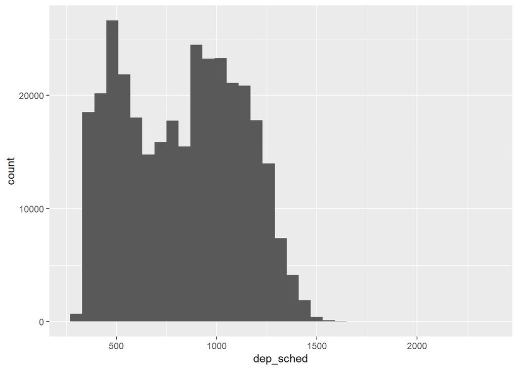

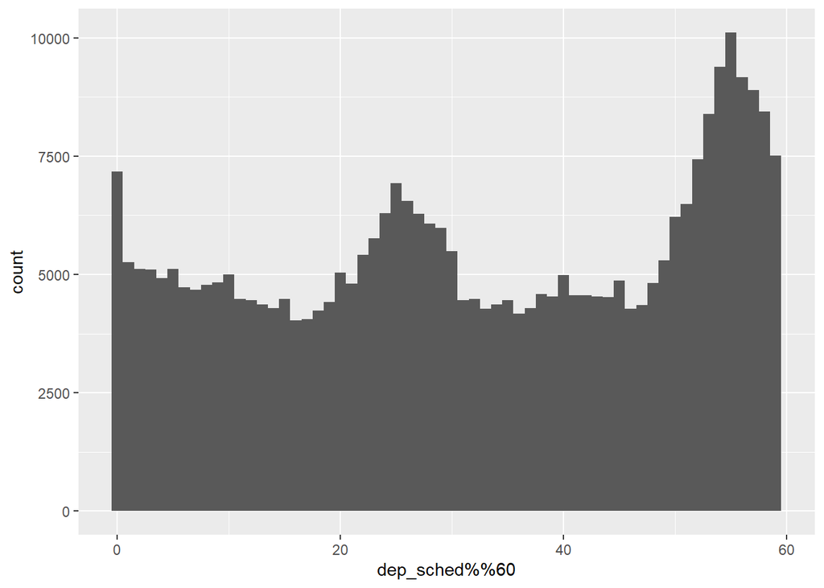

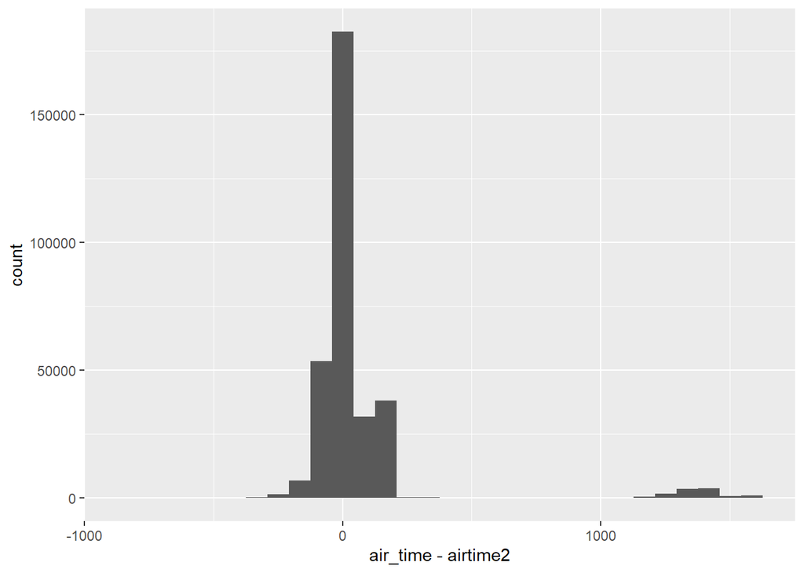

### Resumos Agrupados

| year | month | day | delay |
| --- | --- | --- | --- |
| 2013 | 1 | 1 | 11.548926 |
| 2013 | 1 | 2 | 13.858823 |
| 2013 | 1 | 3 | 10.987832 |
| 2013 | 1 | 4 | 8.951595 |
| 2013 | 1 | 5 | 5.732218 |
| 2013 | 1 | 6 | 7.148014 |
| 2013 | 1 | 7 | 5.417204 |
| 2013 | 1 | 8 | 2.553073 |
| 2013 | 1 | 9 | 2.276477 |
| 2013 | 1 | 10 | 2.844995 |
| 2013 | 1 | 11 | 2.817193 |
| 2013 | 1 | 12 | 1.596491 |
| 2013 | 1 | 13 | 19.873153 |
| 2013 | 1 | 14 | 2.792657 |
| 2013 | 1 | 15 | 0.123723 |
| 2013 | 1 | 16 | 24.612866 |
| 2013 | 1 | 17 | 7.648148 |
| 2013 | 1 | 18 | 6.765864 |
| 2013 | 1 | 19 | 3.475483 |
| 2013 | 1 | 20 | 6.783887 |

### Conclusões Laboratório 2

O laboratório 2 foi mais desafiador do que o primeiro principalmente ao apresentar o resumo agrupado usando o comando summarise() comibinado com o group_by() e novas opções de gráficos dentro do pacote ggplot2. Uso bastante funções de agregação no SQL na minha atual função então sei que elas podem ser muito úteis na exploração dos dados com o R também.

## Laboratório 3

### Combinando múltiplas operações com o pipe

Relação entre a distância e o atraso médio para cada local.

| dest | count | dist | delay |
| --- | --- | --- | --- |
| ABQ | 254 | 1826.0000 | 4.381890 |
| ACK | 265 | 199.0000 | 4.852273 |
| ALB | 439 | 143.0000 | 14.397129 |
| ATL | 17215 | 757.1082 | 11.300113 |
| AUS | 2439 | 1514.2530 | 6.019909 |
| AVL | 275 | 583.5818 | 8.003831 |
| BDL | 443 | 116.0000 | 7.048544 |
| BGR | 375 | 378.0000 | 8.027933 |
| BHM | 297 | 865.9966 | 16.877323 |
| BNA | 6333 | 758.2135 | 11.812459 |
| BOS | 15508 | 190.6370 | 2.914392 |
| BQN | 896 | 1578.9833 | 8.245496 |
| BTV | 2589 | 265.0915 | 8.950996 |
| BUF | 4681 | 296.8084 | 8.945952 |
| BUR | 371 | 2465.0000 | 8.175676 |
| BWI | 1781 | 179.4183 | 10.726734 |
| BZN | 36 | 1882.0000 | 7.600000 |
| CAE | 116 | 603.5517 | 41.764151 |
| CAK | 864 | 397.0000 | 19.698337 |
| CHO | 52 | 305.0000 | 9.500000 |

Observação gráfica da relação. Os atrasos acontecem até uma certa distência e depois passam a diminuir.

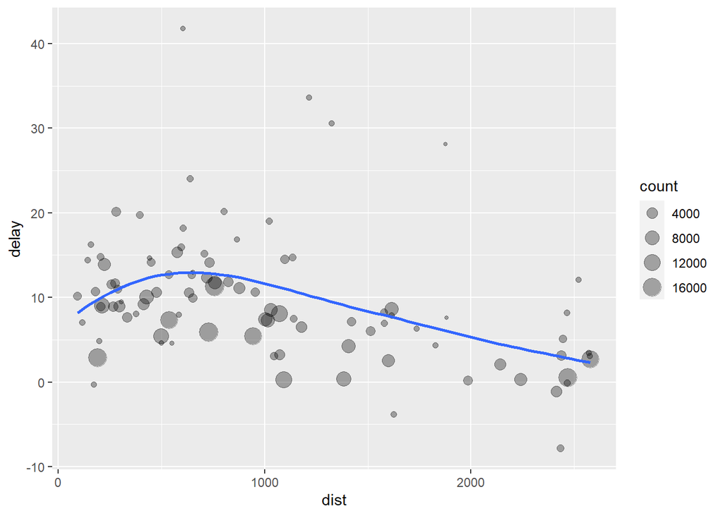

### Valores Faltantes

Agregação sem remover NA.

| year | month | day | mean |
| --- | --- | --- | --- |
| 2013 | 1 | 1 | NA |
| 2013 | 1 | 2 | NA |
| 2013 | 1 | 3 | NA |
| 2013 | 1 | 4 | NA |
| 2013 | 1 | 5 | NA |
| 2013 | 1 | 6 | NA |
| 2013 | 1 | 7 | NA |
| 2013 | 1 | 8 | NA |
| 2013 | 1 | 9 | NA |
| 2013 | 1 | 10 | NA |
| 2013 | 1 | 11 | NA |
| 2013 | 1 | 12 | NA |
| 2013 | 1 | 13 | NA |
| 2013 | 1 | 14 | NA |
| 2013 | 1 | 15 | NA |
| 2013 | 1 | 16 | NA |
| 2013 | 1 | 17 | NA |
| 2013 | 1 | 18 | NA |
| 2013 | 1 | 19 | NA |
| 2013 | 1 | 20 | NA |
| 2013 | 1 | 21 | NA |
| 2013 | 1 | 22 | NA |
| 2013 | 1 | 23 | NA |
| 2013 | 1 | 24 | NA |
| 2013 | 1 | 25 | NA |
| 2013 | 1 | 26 | NA |
| 2013 | 1 | 27 | NA |
| 2013 | 1 | 28 | NA |
| 2013 | 1 | 29 | NA |
| 2013 | 1 | 30 | NA |

[output cut: 335 more lines]

Agregação removendo NA.

| year | month | day | mean |
| --- | --- | --- | --- |
| 2013 | 1 | 1 | 11.4356197 |
| 2013 | 1 | 2 | 13.6778017 |
| 2013 | 1 | 3 | 10.9077778 |
| 2013 | 1 | 4 | 8.9658590 |
| 2013 | 1 | 5 | 5.7322176 |
| 2013 | 1 | 6 | 7.1459590 |
| 2013 | 1 | 7 | 5.4172043 |
| 2013 | 1 | 8 | 2.5582960 |
| 2013 | 1 | 9 | 2.3012318 |
| 2013 | 1 | 10 | 2.8449946 |
| 2013 | 1 | 11 | 2.8331516 |
| 2013 | 1 | 12 | 1.5932452 |
| 2013 | 1 | 13 | 19.6195787 |
| 2013 | 1 | 14 | 2.7984832 |
| 2013 | 1 | 15 | 0.1237230 |
| 2013 | 1 | 16 | 24.4548652 |
| 2013 | 1 | 17 | 7.6852459 |
| 2013 | 1 | 18 | 6.7681319 |
| 2013 | 1 | 19 | 3.3621461 |
| 2013 | 1 | 20 | 6.8040973 |
| 2013 | 1 | 21 | 7.8392461 |
| 2013 | 1 | 22 | 12.4994350 |
| 2013 | 1 | 23 | 10.6103604 |
| 2013 | 1 | 24 | 19.5429515 |
| 2013 | 1 | 25 | 21.7519909 |
| 2013 | 1 | 26 | 7.2131148 |
| 2013 | 1 | 27 | 8.3883375 |
| 2013 | 1 | 28 | 15.0991832 |
| 2013 | 1 | 29 | 2.5489068 |
| 2013 | 1 | 30 | 27.9334171 |

[output cut: 335 more lines]

### Contagem

Tabela do atraso médio por voo

| tailnum | delay |
| --- | --- |
| D942DN | 31.5000000 |
| N0EGMQ | 9.9829545 |
| N10156 | 12.7172414 |
| N102UW | 2.9375000 |
| N103US | -6.9347826 |
| N104UW | 1.8043478 |
| N10575 | 20.6914498 |
| N105UW | -0.2666667 |
| N107US | -5.7317073 |
| N108UW | -1.2500000 |
| N109UW | -2.5208333 |
| N110UW | 2.8000000 |
| N11106 | 14.8809524 |
| N11107 | 15.0143885 |
| N11109 | 14.8510638 |
| N11113 | 15.7619048 |
| N11119 | 30.3065693 |
| N11121 | 10.3061224 |
| N11127 | 13.6050420 |
| N11137 | 20.5514019 |
| N11140 | 18.3120567 |
| N11150 | 8.8914729 |
| N11155 | 12.9895833 |
| N11164 | 21.6496350 |
| N11165 | 8.3466667 |
| N11176 | 20.4045802 |
| N11181 | 9.0750000 |
| N11184 | 6.9843750 |
| N11187 | 11.1904762 |
| N11189 | 6.7372263 |

[output cut: 4007 more lines]

Gráfico de linha do atraso médio por voo

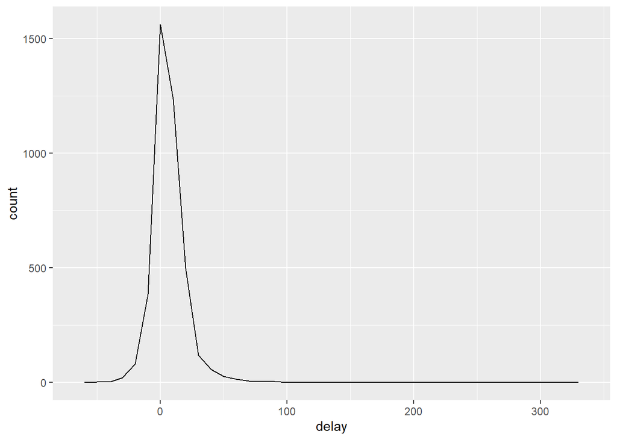

Gráfico de dispersão do atraso médio por voo

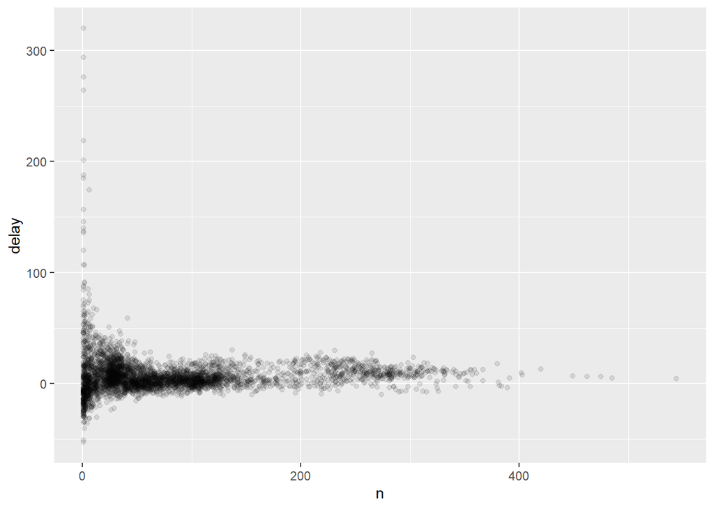

Gráfico de dispersão do atraso médio por voo com filtro dos grupos que possuem menor número de observações (n>25)

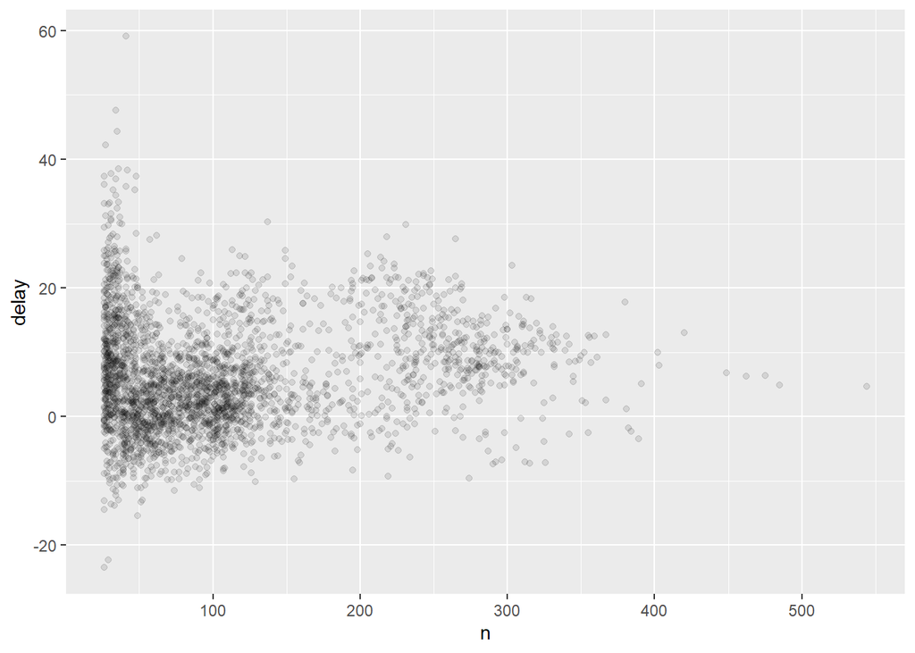

### Funções Resumo

O atraso geral médio (delay1) e o atraso positivo médio (delay2)

| year | month | day | avg_delay1 | avg_delay2 |
| --- | --- | --- | --- | --- |
| 2013 | 1 | 1 | 12.6510229 | 32.48156 |
| 2013 | 1 | 2 | 12.6928879 | 32.02991 |
| 2013 | 1 | 3 | 5.7333333 | 27.66087 |
| 2013 | 1 | 4 | -1.9328194 | 28.30976 |
| 2013 | 1 | 5 | -1.5258020 | 22.55882 |
| 2013 | 1 | 6 | 4.2364294 | 24.37270 |
| 2013 | 1 | 7 | -4.9473118 | 27.76132 |
| 2013 | 1 | 8 | -3.2275785 | 20.78909 |
| 2013 | 1 | 9 | -0.2642777 | 25.63415 |
| 2013 | 1 | 10 | -5.8988159 | 27.34545 |
| 2013 | 1 | 11 | -4.7622683 | 26.15984 |
| 2013 | 1 | 12 | -13.0161527 | 23.47170 |
| 2013 | 1 | 13 | 14.9318463 | 52.54891 |
| 2013 | 1 | 14 | 3.6403034 | 22.44444 |
| 2013 | 1 | 15 | 0.4256527 | 19.71003 |
| 2013 | 1 | 16 | 34.2473623 | 46.08346 |
| 2013 | 1 | 17 | 6.4928962 | 25.60268 |
| 2013 | 1 | 18 | 1.8417582 | 25.05382 |
| 2013 | 1 | 19 | -8.5260805 | 24.28906 |
| 2013 | 1 | 20 | 3.7400768 | 29.02913 |
| 2013 | 1 | 21 | 6.3159645 | 32.24359 |
| 2013 | 1 | 22 | 12.2768362 | 33.88323 |
| 2013 | 1 | 23 | 6.9177928 | 33.05181 |
| 2013 | 1 | 24 | 15.4273128 | 42.08824 |
| 2013 | 1 | 25 | 27.0989761 | 55.73694 |
| 2013 | 1 | 26 | 0.7511177 | 29.05833 |
| 2013 | 1 | 27 | -1.3089330 | 36.02479 |
| 2013 | 1 | 28 | 9.3197200 | 38.70361 |
| 2013 | 1 | 29 | -6.5558113 | 30.13333 |
| 2013 | 1 | 30 | 25.9108040 | 57.42889 |

[output cut: 335 more lines]

### Medidas de dispersão: sd(x), IQR(x), mad(x)

| dest | distance_sd |
| --- | --- |
| EGE | 10.5427653 |
| SAN | 10.3500944 |
| SFO | 10.2160165 |
| HNL | 10.0041972 |
| SEA | 9.9779934 |
| LAS | 9.9077863 |
| PDX | 9.8732987 |
| PHX | 9.8625459 |
| LAX | 9.6571954 |
| IND | 9.4580660 |
| CVG | 9.0182123 |
| SAT | 9.0050836 |
| MEM | 8.5031275 |
| HOU | 8.4677109 |
| MCI | 8.3582273 |
| AUS | 8.3191694 |
| CLE | 8.3123622 |
| DFW | 8.2980374 |
| IAH | 7.9990741 |
| DEN | 7.9811100 |
| TYS | 7.9792719 |
| STL | 7.9162335 |
| BNA | 7.8114176 |
| ORD | 7.7262941 |
| PIT | 7.7240529 |
| BUF | 7.6838764 |
| DTW | 7.5436333 |
| ROC | 7.3956744 |
| SLC | 7.3574582 |
| SDF | 7.3379800 |

[output cut: 74 more lines]

### Contagem

| dest | carriers |
| --- | --- |
| ATL | 7 |
| BOS | 7 |
| CLT | 7 |
| ORD | 7 |
| TPA | 7 |
| AUS | 6 |
| DCA | 6 |
| DTW | 6 |
| IAD | 6 |
| MSP | 6 |
| MSY | 6 |
| PIT | 6 |
| STL | 6 |
| BNA | 5 |
| CLE | 5 |
| DEN | 5 |
| IND | 5 |
| LAS | 5 |
| LAX | 5 |
| PBI | 5 |
| PHL | 5 |
| PHX | 5 |
| RDU | 5 |
| SEA | 5 |
| SFO | 5 |
| BUF | 4 |
| BWI | 4 |
| CHS | 4 |
| CVG | 4 |
| DFW | 4 |

[output cut: 74 more lines]

Contatem dos destinos.

| dest | n |
| --- | --- |
| ABQ | 254 |
| ACK | 264 |
| ALB | 418 |
| ANC | 8 |
| ATL | 16837 |
| AUS | 2411 |
| AVL | 261 |
| BDL | 412 |
| BGR | 358 |
| BHM | 269 |
| BNA | 6084 |
| BOS | 15022 |
| BQN | 888 |
| BTV | 2510 |
| BUF | 4570 |
| BUR | 370 |
| BWI | 1687 |
| BZN | 35 |
| CAE | 106 |
| CAK | 842 |
| CHO | 46 |
| CHS | 2759 |
| CLE | 4394 |
| CLT | 13674 |
| CMH | 3326 |
| CRW | 134 |
| CVG | 3725 |
| DAY | 1399 |
| DCA | 9111 |
| DEN | 7169 |

[output cut: 74 more lines]

### Contagens e proporções de valores lógicos: sum(x > 10), mean(y == 0)

Quantos voos restam antes das 5 da manhã? (estes podem indicar atrasos de voos do dia anterior):

| year | month | day | n_early |
| --- | --- | --- | --- |
| 2013 | 1 | 1 | 129 |
| 2013 | 1 | 2 | 176 |
| 2013 | 1 | 3 | 166 |
| 2013 | 1 | 4 | 171 |
| 2013 | 1 | 5 | 137 |
| 2013 | 1 | 6 | 123 |
| 2013 | 1 | 7 | 177 |
| 2013 | 1 | 8 | 171 |
| 2013 | 1 | 9 | 170 |
| 2013 | 1 | 10 | 176 |
| 2013 | 1 | 11 | 178 |
| 2013 | 1 | 12 | 133 |
| 2013 | 1 | 13 | 114 |
| 2013 | 1 | 14 | 178 |
| 2013 | 1 | 15 | 168 |
| 2013 | 1 | 16 | 160 |
| 2013 | 1 | 17 | 176 |
| 2013 | 1 | 18 | 177 |
| 2013 | 1 | 19 | 135 |
| 2013 | 1 | 20 | 110 |
| 2013 | 1 | 21 | 172 |
| 2013 | 1 | 22 | 170 |
| 2013 | 1 | 23 | 170 |
| 2013 | 1 | 24 | 172 |
| 2013 | 1 | 25 | 173 |
| 2013 | 1 | 26 | 132 |
| 2013 | 1 | 27 | 115 |
| 2013 | 1 | 28 | 176 |
| 2013 | 1 | 29 | 171 |
| 2013 | 1 | 30 | 167 |

[output cut: 335 more lines]

Que proporção de voos estavam atrasados em mais de uma hora?

| year | month | day | hour_prop |
| --- | --- | --- | --- |
| 2013 | 1 | 1 | 0.0722022 |
| 2013 | 1 | 2 | 0.0851293 |
| 2013 | 1 | 3 | 0.0566667 |
| 2013 | 1 | 4 | 0.0396476 |
| 2013 | 1 | 5 | 0.0348675 |
| 2013 | 1 | 6 | 0.0470446 |
| 2013 | 1 | 7 | 0.0333333 |
| 2013 | 1 | 8 | 0.0213004 |
| 2013 | 1 | 9 | 0.0201568 |
| 2013 | 1 | 10 | 0.0182992 |
| 2013 | 1 | 11 | 0.0250818 |
| 2013 | 1 | 12 | 0.0102790 |
| 2013 | 1 | 13 | 0.1474597 |
| 2013 | 1 | 14 | 0.0270856 |
| 2013 | 1 | 15 | 0.0272418 |
| 2013 | 1 | 16 | 0.1910903 |
| 2013 | 1 | 17 | 0.0557377 |
| 2013 | 1 | 18 | 0.0351648 |
| 2013 | 1 | 19 | 0.0208644 |
| 2013 | 1 | 20 | 0.0588988 |
| 2013 | 1 | 21 | 0.0665188 |
| 2013 | 1 | 22 | 0.0949153 |
| 2013 | 1 | 23 | 0.0698198 |
| 2013 | 1 | 24 | 0.1145374 |
| 2013 | 1 | 25 | 0.1740614 |
| 2013 | 1 | 26 | 0.0357675 |
| 2013 | 1 | 27 | 0.0558313 |
| 2013 | 1 | 28 | 0.0921820 |
| 2013 | 1 | 29 | 0.0322209 |
| 2013 | 1 | 30 | 0.2035176 |

[output cut: 335 more lines]

### Agrupamento por múltiplas variáveis

Aplicando a função group_by por flight, year, month e day.

| year | month | day | dep_time | sched_dep_time | dep_delay | arr_time | sched_arr_time | arr_delay | carrier | flight | tailnum | origin | dest | air_time | distance | hour | minute | time_hour | airtime2 | dep_sched |
| --- | --- | --- | --- | --- | --- | --- | --- | --- | --- | --- | --- | --- | --- | --- | --- | --- | --- | --- | --- | --- |
| 2013 | 1 | 1 | 315 | 515 | 2 | 510 | 819 | 11 | UA | 1545 | N14228 | EWR | IAH | 227 | 1400 | 5 | 15 | 2013-01-01 05:00:00 | 195 | 317 |
| 2013 | 1 | 1 | 329 | 529 | 4 | 530 | 830 | 20 | UA | 1714 | N24211 | LGA | IAH | 227 | 1416 | 5 | 29 | 2013-01-01 05:00:00 | 201 | 333 |
| 2013 | 1 | 1 | 340 | 540 | 2 | 563 | 850 | 33 | AA | 1141 | N619AA | JFK | MIA | 160 | 1089 | 5 | 40 | 2013-01-01 05:00:00 | 223 | 342 |
| 2013 | 1 | 1 | 345 | 545 | -1 | 604 | 1022 | -18 | B6 | 725 | N804JB | JFK | BQN | 183 | 1576 | 5 | 45 | 2013-01-01 05:00:00 | 259 | 344 |
| 2013 | 1 | 1 | 360 | 600 | -6 | 492 | 837 | -25 | DL | 461 | N668DN | LGA | ATL | 116 | 762 | 6 | 0 | 2013-01-01 06:00:00 | 132 | 354 |
| 2013 | 1 | 1 | 358 | 558 | -4 | 460 | 728 | 12 | UA | 1696 | N39463 | EWR | ORD | 150 | 719 | 5 | 58 | 2013-01-01 05:00:00 | 102 | 354 |
| 2013 | 1 | 1 | 360 | 600 | -5 | 553 | 854 | 19 | B6 | 507 | N516JB | EWR | FLL | 158 | 1065 | 6 | 0 | 2013-01-01 06:00:00 | 193 | 355 |
| 2013 | 1 | 1 | 360 | 600 | -3 | 429 | 723 | -14 | EV | 5708 | N829AS | LGA | IAD | 53 | 229 | 6 | 0 | 2013-01-01 06:00:00 | 69 | 357 |
| 2013 | 1 | 1 | 360 | 600 | -3 | 518 | 846 | -8 | B6 | 79 | N593JB | JFK | MCO | 140 | 944 | 6 | 0 | 2013-01-01 06:00:00 | 158 | 357 |
| 2013 | 1 | 1 | 360 | 600 | -2 | 473 | 745 | 8 | AA | 301 | N3ALAA | LGA | ORD | 138 | 733 | 6 | 0 | 2013-01-01 06:00:00 | 113 | 358 |
| 2013 | 1 | 1 | 360 | 600 | -2 | 529 | 851 | -2 | B6 | 49 | N793JB | JFK | PBI | 149 | 1028 | 6 | 0 | 2013-01-01 06:00:00 | 169 | 358 |
| 2013 | 1 | 1 | 360 | 600 | -2 | 533 | 856 | -3 | B6 | 71 | N657JB | JFK | TPA | 158 | 1005 | 6 | 0 | 2013-01-01 06:00:00 | 173 | 358 |
| 2013 | 1 | 1 | 360 | 600 | -2 | 564 | 917 | 7 | UA | 194 | N29129 | JFK | LAX | 345 | 2475 | 6 | 0 | 2013-01-01 06:00:00 | 204 | 358 |
| 2013 | 1 | 1 | 360 | 600 | -2 | 563 | 937 | -14 | UA | 1124 | N53441 | EWR | SFO | 361 | 2565 | 6 | 0 | 2013-01-01 06:00:00 | 203 | 358 |
| 2013 | 1 | 1 | 360 | 600 | -1 | 581 | 910 | 31 | AA | 707 | N3DUAA | LGA | DFW | 257 | 1389 | 6 | 0 | 2013-01-01 06:00:00 | 221 | 359 |
| 2013 | 1 | 1 | 359 | 559 | 0 | 422 | 706 | -4 | B6 | 1806 | N708JB | JFK | BOS | 44 | 187 | 5 | 59 | 2013-01-01 05:00:00 | 63 | 359 |
| 2013 | 1 | 1 | 360 | 600 | -1 | 534 | 902 | -8 | UA | 1187 | N76515 | EWR | LAS | 337 | 2227 | 6 | 0 | 2013-01-01 06:00:00 | 174 | 359 |
| 2013 | 1 | 1 | 360 | 600 | 0 | 531 | 858 | -7 | B6 | 371 | N595JB | LGA | FLL | 152 | 1076 | 6 | 0 | 2013-01-01 06:00:00 | 171 | 360 |
| 2013 | 1 | 1 | 360 | 600 | 0 | 517 | 825 | 12 | MQ | 4650 | N542MQ | LGA | ATL | 134 | 762 | 6 | 0 | 2013-01-01 06:00:00 | 157 | 360 |
| 2013 | 1 | 1 | 360 | 600 | 1 | 524 | 850 | -6 | B6 | 343 | N644JB | EWR | PBI | 147 | 1023 | 6 | 0 | 2013-01-01 06:00:00 | 164 | 361 |

Agrupamento do número de voos por dia.

| year | month | day | flights |
| --- | --- | --- | --- |
| 2013 | 1 | 1 | 842 |
| 2013 | 1 | 2 | 943 |
| 2013 | 1 | 3 | 914 |
| 2013 | 1 | 4 | 915 |
| 2013 | 1 | 5 | 720 |
| 2013 | 1 | 6 | 832 |
| 2013 | 1 | 7 | 933 |
| 2013 | 1 | 8 | 899 |
| 2013 | 1 | 9 | 902 |
| 2013 | 1 | 10 | 932 |
| 2013 | 1 | 11 | 930 |
| 2013 | 1 | 12 | 690 |
| 2013 | 1 | 13 | 828 |
| 2013 | 1 | 14 | 928 |
| 2013 | 1 | 15 | 894 |
| 2013 | 1 | 16 | 901 |
| 2013 | 1 | 17 | 927 |
| 2013 | 1 | 18 | 924 |
| 2013 | 1 | 19 | 674 |
| 2013 | 1 | 20 | 786 |
| 2013 | 1 | 21 | 912 |
| 2013 | 1 | 22 | 890 |
| 2013 | 1 | 23 | 897 |
| 2013 | 1 | 24 | 925 |
| 2013 | 1 | 25 | 922 |
| 2013 | 1 | 26 | 680 |
| 2013 | 1 | 27 | 823 |
| 2013 | 1 | 28 | 923 |
| 2013 | 1 | 29 | 890 |
| 2013 | 1 | 30 | 900 |

[output cut: 335 more lines]

Agrupamento do número de voos por mês.

| year | month | flights |
| --- | --- | --- |
| 2013 | 1 | 27004 |
| 2013 | 2 | 24951 |
| 2013 | 3 | 28834 |
| 2013 | 4 | 28330 |
| 2013 | 5 | 28796 |
| 2013 | 6 | 28243 |
| 2013 | 7 | 29425 |
| 2013 | 8 | 29327 |
| 2013 | 9 | 27574 |
| 2013 | 10 | 28889 |
| 2013 | 11 | 27268 |
| 2013 | 12 | 28135 |

Agrupamento do número de voos por ano.

| year | flights |
| --- | --- |
| 2013 | 336776 |

### Mudanças Agrupadas e Filtros

Aplicando a função filter() para os voos mais atrasados.

| year | month | day | dep_delay | arr_delay | distance | air_time |
| --- | --- | --- | --- | --- | --- | --- |
| 2013 | 1 | 1 | 853 | 851 | 184 | 41 |
| 2013 | 1 | 1 | 290 | 338 | 1134 | 213 |
| 2013 | 1 | 1 | 260 | 263 | 266 | 46 |
| 2013 | 1 | 1 | 157 | 174 | 213 | 60 |
| 2013 | 1 | 1 | 216 | 222 | 708 | 121 |
| 2013 | 1 | 1 | 255 | 250 | 589 | 115 |
| 2013 | 1 | 1 | 285 | 246 | 1085 | 146 |
| 2013 | 1 | 1 | 192 | 191 | 199 | 44 |
| 2013 | 1 | 1 | 379 | 456 | 1092 | 222 |
| 2013 | 1 | 2 | 224 | 207 | 550 | 94 |
| 2013 | 1 | 2 | 268 | 288 | 1092 | 203 |
| 2013 | 1 | 2 | 334 | 323 | 937 | 150 |
| 2013 | 1 | 2 | 337 | 368 | 2586 | 346 |
| 2013 | 1 | 2 | 168 | 180 | 533 | 102 |
| 2013 | 1 | 2 | 180 | 176 | 213 | 49 |
| 2013 | 1 | 2 | 164 | 182 | 463 | 103 |
| 2013 | 1 | 2 | 379 | 359 | 1620 | 228 |
| 2013 | 1 | 2 | 175 | 252 | 1325 | 286 |
| 2013 | 1 | 3 | 185 | 172 | 301 | 58 |
| 2013 | 1 | 3 | 156 | 143 | 1576 | 186 |

Destinos mais populares (com mais de 365 voos)

| year | month | day | dep_time | sched_dep_time | dep_delay | arr_time | sched_arr_time | arr_delay | carrier | flight | tailnum | origin | dest | air_time | distance | hour | minute | time_hour | airtime2 | dep_sched |
| --- | --- | --- | --- | --- | --- | --- | --- | --- | --- | --- | --- | --- | --- | --- | --- | --- | --- | --- | --- | --- |
| 2013 | 1 | 1 | 315 | 515 | 2 | 510 | 819 | 11 | UA | 1545 | N14228 | EWR | IAH | 227 | 1400 | 5 | 15 | 2013-01-01 05:00:00 | 195 | 317 |
| 2013 | 1 | 1 | 329 | 529 | 4 | 530 | 830 | 20 | UA | 1714 | N24211 | LGA | IAH | 227 | 1416 | 5 | 29 | 2013-01-01 05:00:00 | 201 | 333 |
| 2013 | 1 | 1 | 340 | 540 | 2 | 563 | 850 | 33 | AA | 1141 | N619AA | JFK | MIA | 160 | 1089 | 5 | 40 | 2013-01-01 05:00:00 | 223 | 342 |
| 2013 | 1 | 1 | 345 | 545 | -1 | 604 | 1022 | -18 | B6 | 725 | N804JB | JFK | BQN | 183 | 1576 | 5 | 45 | 2013-01-01 05:00:00 | 259 | 344 |
| 2013 | 1 | 1 | 360 | 600 | -6 | 492 | 837 | -25 | DL | 461 | N668DN | LGA | ATL | 116 | 762 | 6 | 0 | 2013-01-01 06:00:00 | 132 | 354 |
| 2013 | 1 | 1 | 358 | 558 | -4 | 460 | 728 | 12 | UA | 1696 | N39463 | EWR | ORD | 150 | 719 | 5 | 58 | 2013-01-01 05:00:00 | 102 | 354 |
| 2013 | 1 | 1 | 360 | 600 | -5 | 553 | 854 | 19 | B6 | 507 | N516JB | EWR | FLL | 158 | 1065 | 6 | 0 | 2013-01-01 06:00:00 | 193 | 355 |
| 2013 | 1 | 1 | 360 | 600 | -3 | 429 | 723 | -14 | EV | 5708 | N829AS | LGA | IAD | 53 | 229 | 6 | 0 | 2013-01-01 06:00:00 | 69 | 357 |
| 2013 | 1 | 1 | 360 | 600 | -3 | 518 | 846 | -8 | B6 | 79 | N593JB | JFK | MCO | 140 | 944 | 6 | 0 | 2013-01-01 06:00:00 | 158 | 357 |
| 2013 | 1 | 1 | 360 | 600 | -2 | 473 | 745 | 8 | AA | 301 | N3ALAA | LGA | ORD | 138 | 733 | 6 | 0 | 2013-01-01 06:00:00 | 113 | 358 |
| 2013 | 1 | 1 | 360 | 600 | -2 | 529 | 851 | -2 | B6 | 49 | N793JB | JFK | PBI | 149 | 1028 | 6 | 0 | 2013-01-01 06:00:00 | 169 | 358 |
| 2013 | 1 | 1 | 360 | 600 | -2 | 533 | 856 | -3 | B6 | 71 | N657JB | JFK | TPA | 158 | 1005 | 6 | 0 | 2013-01-01 06:00:00 | 173 | 358 |
| 2013 | 1 | 1 | 360 | 600 | -2 | 564 | 917 | 7 | UA | 194 | N29129 | JFK | LAX | 345 | 2475 | 6 | 0 | 2013-01-01 06:00:00 | 204 | 358 |
| 2013 | 1 | 1 | 360 | 600 | -2 | 563 | 937 | -14 | UA | 1124 | N53441 | EWR | SFO | 361 | 2565 | 6 | 0 | 2013-01-01 06:00:00 | 203 | 358 |
| 2013 | 1 | 1 | 360 | 600 | -1 | 581 | 910 | 31 | AA | 707 | N3DUAA | LGA | DFW | 257 | 1389 | 6 | 0 | 2013-01-01 06:00:00 | 221 | 359 |
| 2013 | 1 | 1 | 359 | 559 | 0 | 422 | 706 | -4 | B6 | 1806 | N708JB | JFK | BOS | 44 | 187 | 5 | 59 | 2013-01-01 05:00:00 | 63 | 359 |
| 2013 | 1 | 1 | 360 | 600 | -1 | 534 | 902 | -8 | UA | 1187 | N76515 | EWR | LAS | 337 | 2227 | 6 | 0 | 2013-01-01 06:00:00 | 174 | 359 |
| 2013 | 1 | 1 | 360 | 600 | 0 | 531 | 858 | -7 | B6 | 371 | N595JB | LGA | FLL | 152 | 1076 | 6 | 0 | 2013-01-01 06:00:00 | 171 | 360 |
| 2013 | 1 | 1 | 360 | 600 | 0 | 517 | 825 | 12 | MQ | 4650 | N542MQ | LGA | ATL | 134 | 762 | 6 | 0 | 2013-01-01 06:00:00 | 157 | 360 |
| 2013 | 1 | 1 | 360 | 600 | 1 | 524 | 850 | -6 | B6 | 343 | N644JB | EWR | PBI | 147 | 1023 | 6 | 0 | 2013-01-01 06:00:00 | 164 | 361 |

Agrupamento da tabela anterior aplicando filtro de atrasos de chegadas positivos e adicionando uma coluna de proporção do atraso

| year | month | day | dest | arr_delay | prop_delay |
| --- | --- | --- | --- | --- | --- |
| 2013 | 1 | 1 | IAH | 11 | 0.0001107 |
| 2013 | 1 | 1 | IAH | 20 | 0.0002012 |
| 2013 | 1 | 1 | MIA | 33 | 0.0002350 |
| 2013 | 1 | 1 | ORD | 12 | 0.0000424 |
| 2013 | 1 | 1 | FLL | 19 | 0.0000938 |
| 2013 | 1 | 1 | ORD | 8 | 0.0000283 |
| 2013 | 1 | 1 | LAX | 7 | 0.0000344 |
| 2013 | 1 | 1 | DFW | 31 | 0.0002818 |
| 2013 | 1 | 1 | ATL | 12 | 0.0000400 |
| 2013 | 1 | 1 | DTW | 16 | 0.0001157 |
| 2013 | 1 | 1 | ORD | 32 | 0.0001131 |
| 2013 | 1 | 1 | SFO | 14 | 0.0000682 |
| 2013 | 1 | 1 | RSW | 4 | 0.0000944 |
| 2013 | 1 | 1 | PHX | 3 | 0.0000475 |
| 2013 | 1 | 1 | MIA | 5 | 0.0000356 |
| 2013 | 1 | 1 | IAH | 1 | 0.0000101 |
| 2013 | 1 | 1 | MSP | 29 | 0.0002486 |
| 2013 | 1 | 1 | MSP | 10 | 0.0000857 |
| 2013 | 1 | 1 | LAX | 29 | 0.0001427 |
| 2013 | 1 | 1 | ORD | 14 | 0.0000495 |

## Laboratório 4

Gráfico de carat vs price do data frame diamonds.

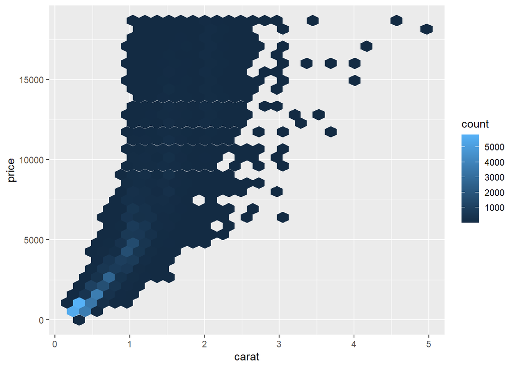

### Conclusões Laboratório 4

O foco desde laboratório foi usar o editor de scripts e configurar diretórios para a criação de projetos. Também pesquisei que sobre o uso da opção “Version Control” que usam o Github e o Git Bash e que parece ser muito útil para projetos em grupo. Ao final do laboratório foi feita a plotagem de um gráfico do data frame diamonds com a concentração (contagem) de diamantes por carat e price.

## Laboratório 5

### Análise Exploratória de Dados

Amostra do data frame diamonds

| carat | cut | color | clarity | depth | table | price | x | y | z |
| --- | --- | --- | --- | --- | --- | --- | --- | --- | --- |
| 0.23 | Ideal | E | SI2 | 61.5 | 55 | 326 | 3.95 | 3.98 | 2.43 |
| 0.21 | Premium | E | SI1 | 59.8 | 61 | 326 | 3.89 | 3.84 | 2.31 |
| 0.23 | Good | E | VS1 | 56.9 | 65 | 327 | 4.05 | 4.07 | 2.31 |
| 0.29 | Premium | I | VS2 | 62.4 | 58 | 334 | 4.20 | 4.23 | 2.63 |
| 0.31 | Good | J | SI2 | 63.3 | 58 | 335 | 4.34 | 4.35 | 2.75 |
| 0.24 | Very Good | J | VVS2 | 62.8 | 57 | 336 | 3.94 | 3.96 | 2.48 |
| 0.24 | Very Good | I | VVS1 | 62.3 | 57 | 336 | 3.95 | 3.98 | 2.47 |
| 0.26 | Very Good | H | SI1 | 61.9 | 55 | 337 | 4.07 | 4.11 | 2.53 |
| 0.22 | Fair | E | VS2 | 65.1 | 61 | 337 | 3.87 | 3.78 | 2.49 |
| 0.23 | Very Good | H | VS1 | 59.4 | 61 | 338 | 4.00 | 4.05 | 2.39 |
| 0.30 | Good | J | SI1 | 64.0 | 55 | 339 | 4.25 | 4.28 | 2.73 |
| 0.23 | Ideal | J | VS1 | 62.8 | 56 | 340 | 3.93 | 3.90 | 2.46 |
| 0.22 | Premium | F | SI1 | 60.4 | 61 | 342 | 3.88 | 3.84 | 2.33 |
| 0.31 | Ideal | J | SI2 | 62.2 | 54 | 344 | 4.35 | 4.37 | 2.71 |
| 0.20 | Premium | E | SI2 | 60.2 | 62 | 345 | 3.79 | 3.75 | 2.27 |
| 0.32 | Premium | E | I1 | 60.9 | 58 | 345 | 4.38 | 4.42 | 2.68 |
| 0.30 | Ideal | I | SI2 | 62.0 | 54 | 348 | 4.31 | 4.34 | 2.68 |
| 0.30 | Good | J | SI1 | 63.4 | 54 | 351 | 4.23 | 4.29 | 2.70 |
| 0.30 | Good | J | SI1 | 63.8 | 56 | 351 | 4.23 | 4.26 | 2.71 |
| 0.30 | Very Good | J | SI1 | 62.7 | 59 | 351 | 4.21 | 4.27 | 2.66 |

Gráfico de barras do data frame diamonds

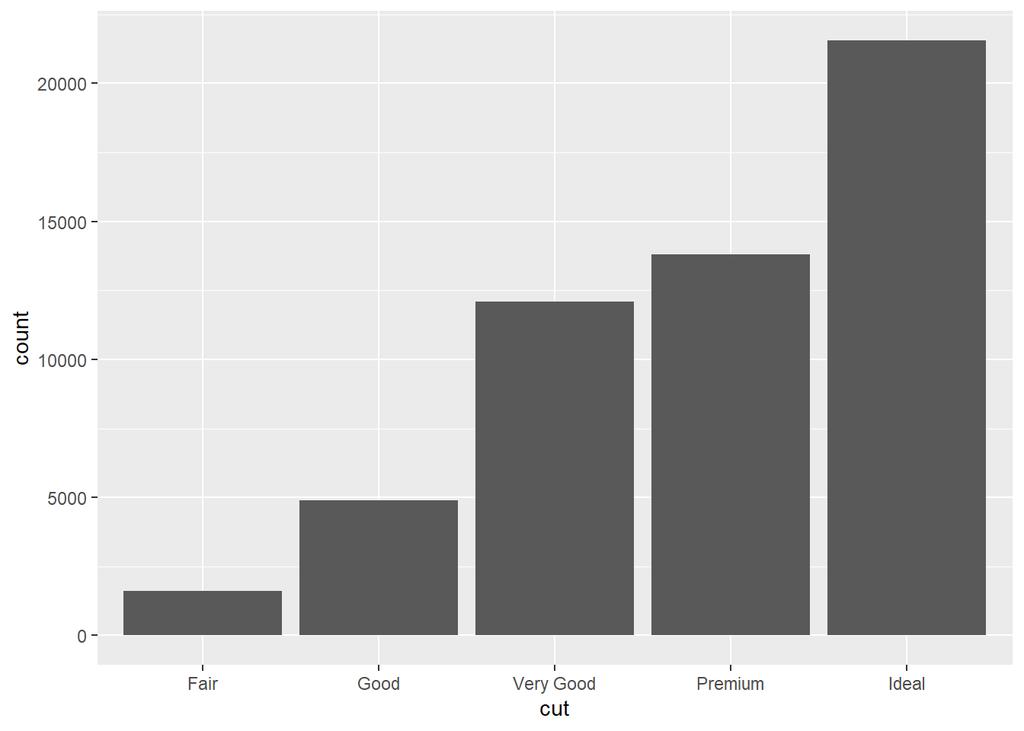

Histograma com largura de barra 0.5 do data frame diamonds

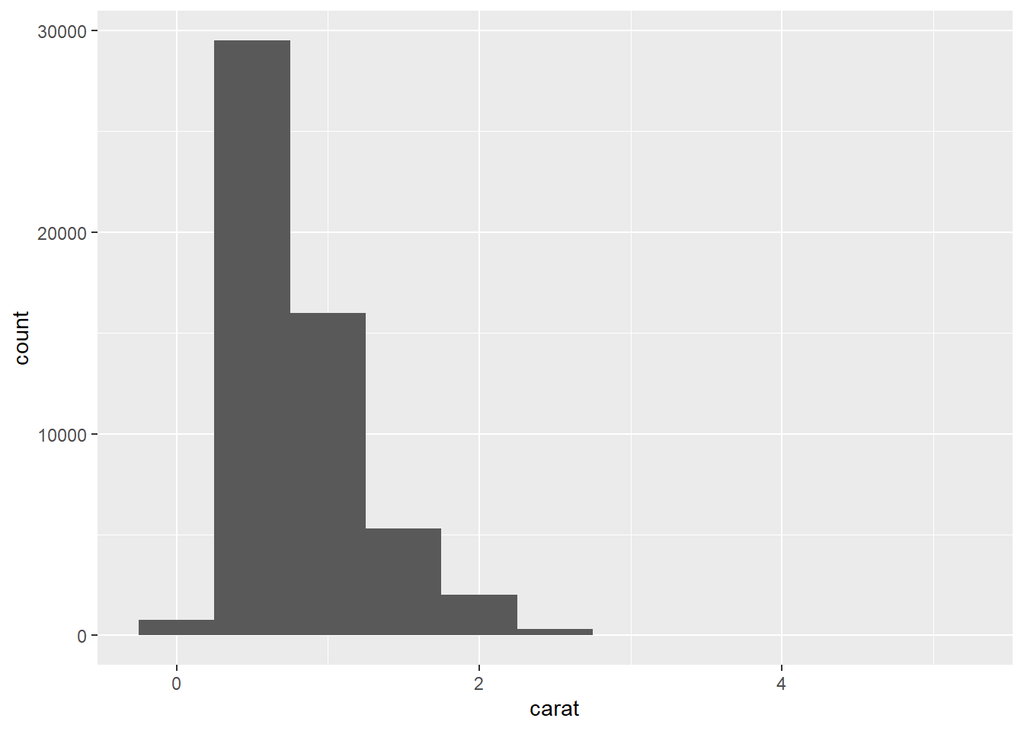

Histograma com largura de barra 0.1 do data frame diamonds

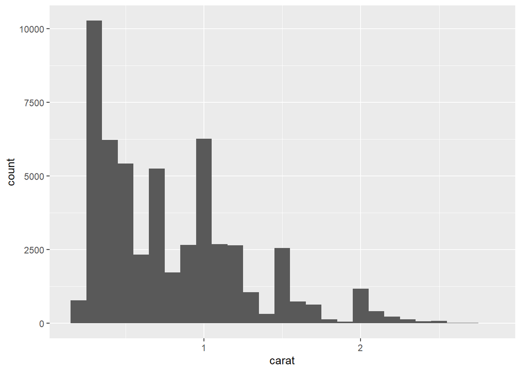

Plotagem da contagem com linhas para visualizar a sobreposição por cortes.

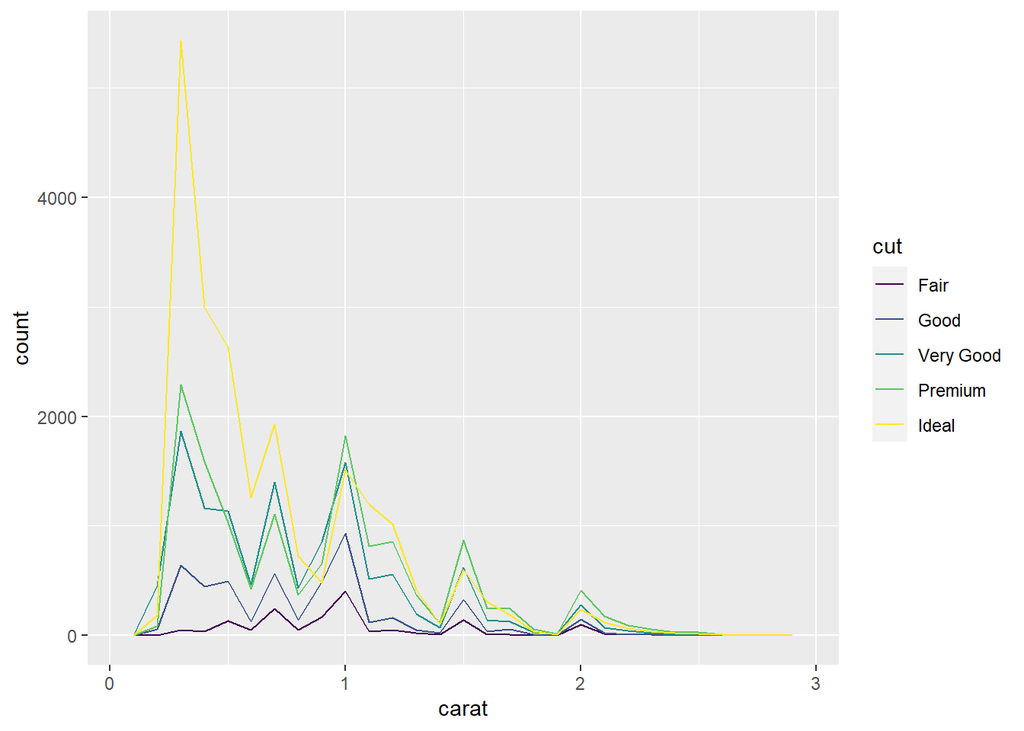

### Valores Típicos

Histograma com largura de barra 0.01 do data frame diamonds

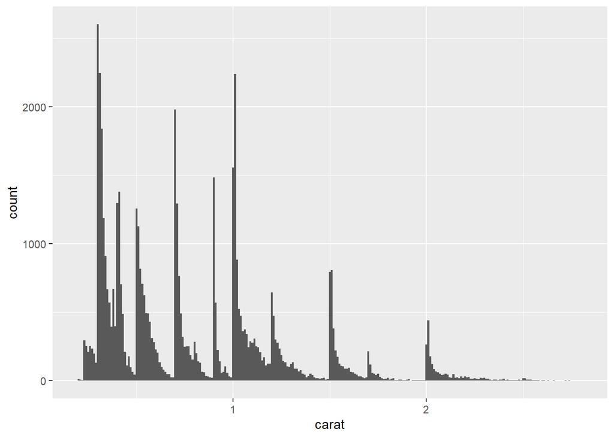

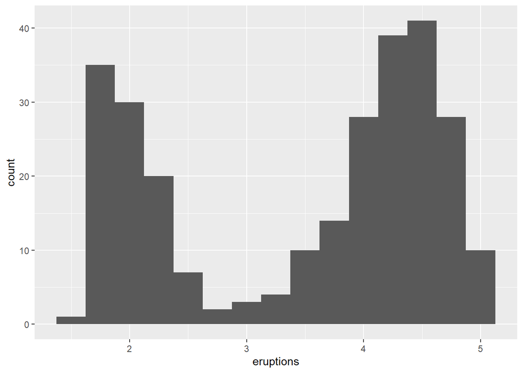

### Valores Incomuns

Histograma de y com largura de barra 0.5 do data frame diamonds

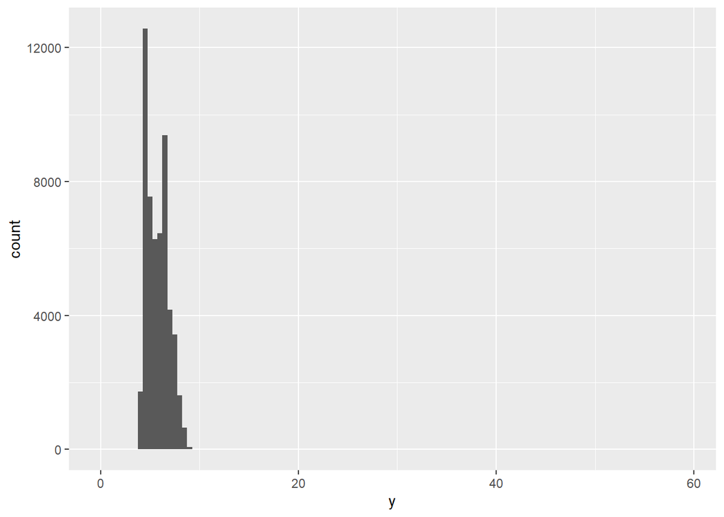

Histograma de y com largura de barra 0.5 do data frame diamonds ampliado para count entre 0 e 50

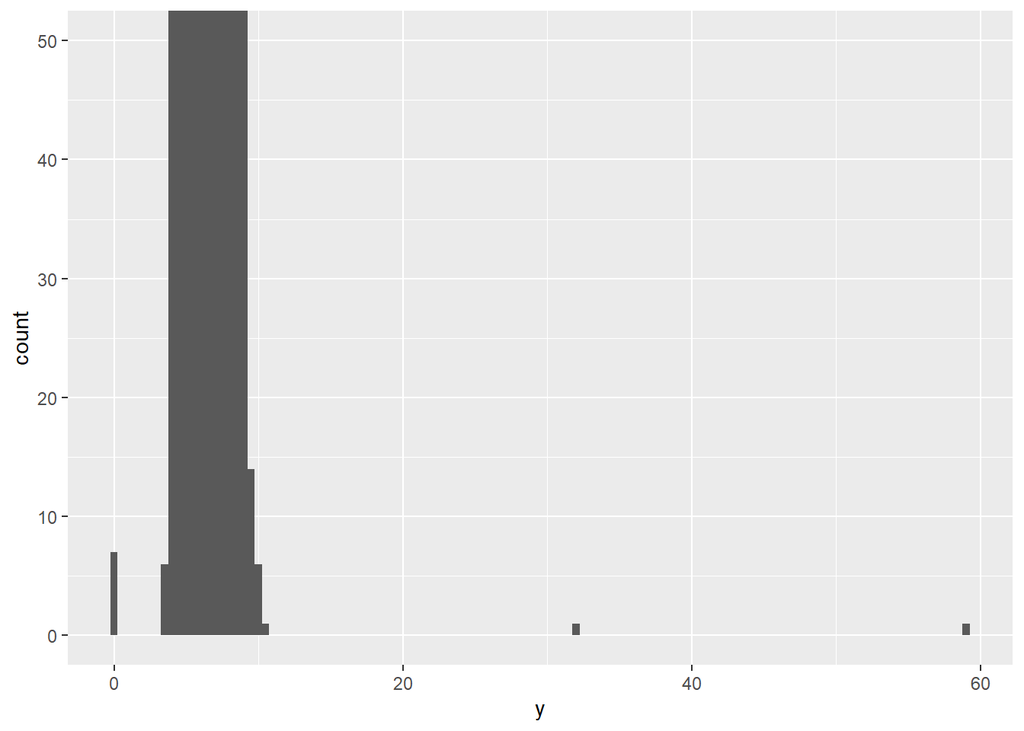

A partir do gráfico anterior foi possível notar que existem três valores incomuns: 0, ~30 e ~60. Abaixo segue a tabela da dimensão dessas ocorrencias e os preços.

| price | x | y | z |
| --- | --- | --- | --- |
| 5139 | 0.00 | 0.0 | 0.00 |
| 6381 | 0.00 | 0.0 | 0.00 |
| 12800 | 0.00 | 0.0 | 0.00 |
| 15686 | 0.00 | 0.0 | 0.00 |
| 18034 | 0.00 | 0.0 | 0.00 |
| 2130 | 0.00 | 0.0 | 0.00 |
| 2130 | 0.00 | 0.0 | 0.00 |
| 2075 | 5.15 | 31.8 | 5.12 |
| 12210 | 8.09 | 58.9 | 8.06 |

### Valores Faltantes

os valores incorretos foram substituidos por ‘NA’ e plotados em um gráfico de dispersão. Aparentemente o a relação entre x e y é uma correlação positiva que segue uma função linear.

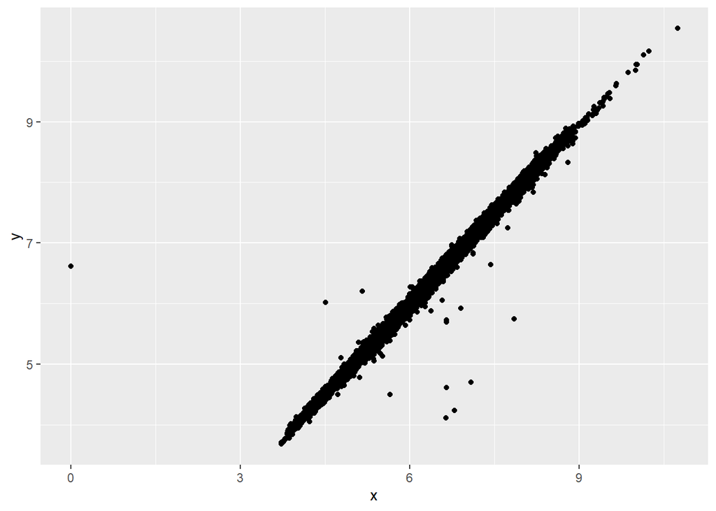

### Covariação

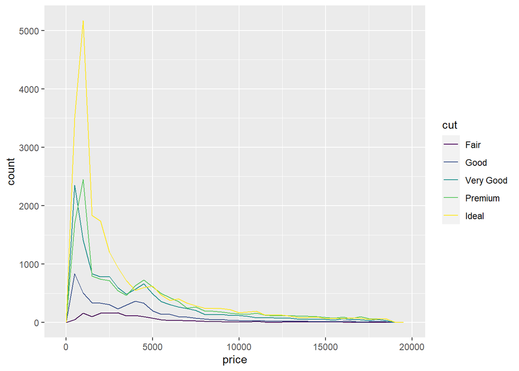

Em vez de exibir a contagem, vamos exibir density, que é a contagem padronizada de modo que a área sob cada polígono de frequência é um.

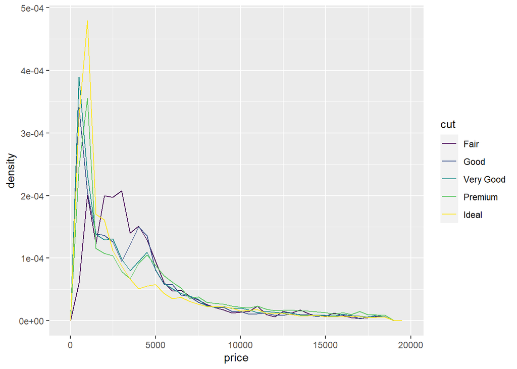

### Boxplot

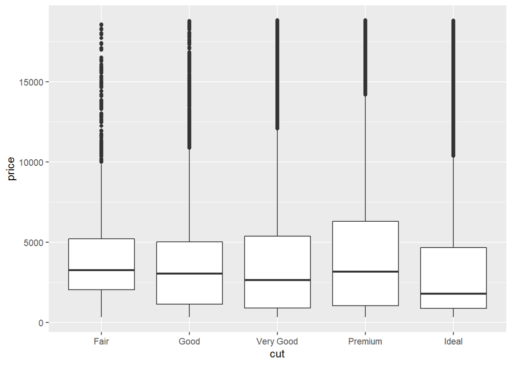

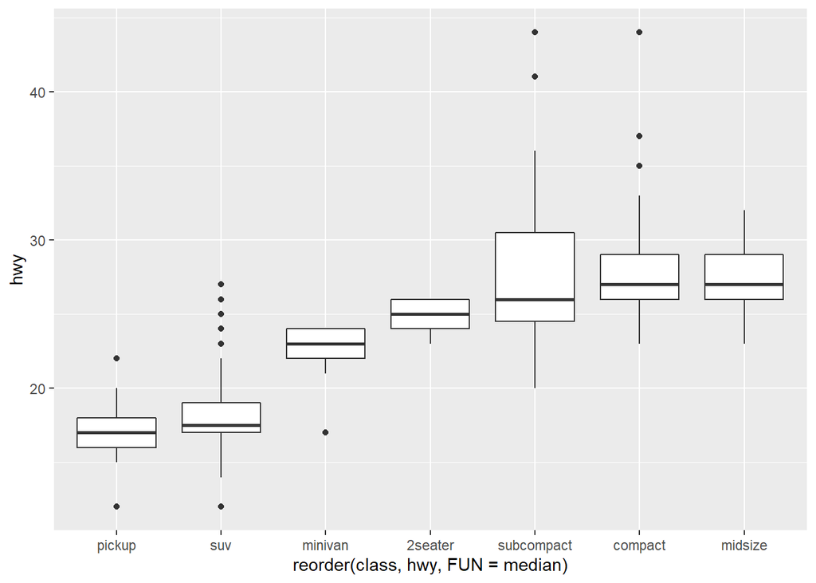

Rotacionando o gráfico de boxplot

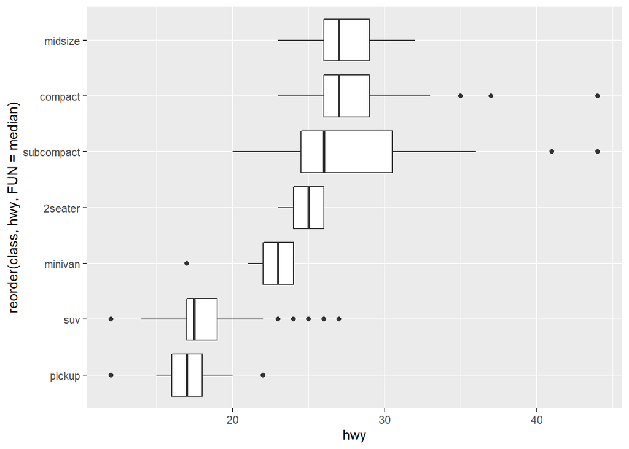

### Duas variáveis categóricas

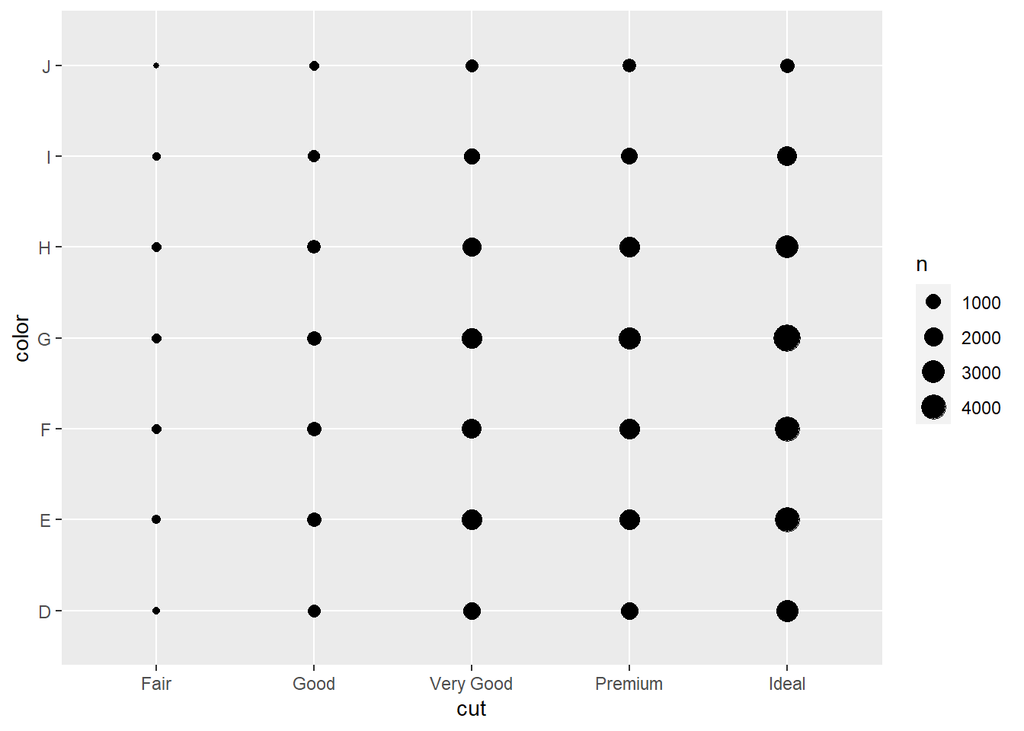